# Assignment 08

Statistical Computing and Empirical Methods

## A word of advice

Think of the SCEM labs like going to the gym: if you pay for gym membership, but instead of working out you use a machine to lift the weights for you, you won’t grow any muscle.

ChatGPT, DeepSeek, Claude and other GenAI tools can provide answers to most of the questions below. Before you try that, please consider the following: answering the specific questions below is not the point of this assignment. Instead, the questions are designed to give you the chance to develop a better understanding of estimation concepts and a certain level of **statistical thinking**. These are essential skills for any data scientist, even if they end up using generative AI - to write an effective prompt and to catch the common (often subtle) errors that AI produces when trying to solve anything non-trivial.

A very important part of this learning involves not having the answers ready-made for you but instead taking the time to actually search for the answer, trying something, getting it wrong, and trying again.

So, make the best use of this session. The assignments are not marked, so it is much better to try them yourself even if you get incorrect answers (you’ll be able to correct yourself later when you receive feedback) than to submit a perfect, but GPT’d solution.

## Introduction

Before starting, make sure you have reviewed the Week 8 lecture slides.

This assignment will be done in **RStudio**. **You do not need to submit anything for this assessment.** Feedback will be provided on the labs.

## Introduction

In this lab we will discuss data preprocessing (DPP), which corresponds to the second part of Task II in the final SCEM coursework. DPP, also sometimes called *data preparation*, is the bridge between understanding the data (during EDA) and building models to extract insights or predictions for the data-generating process. It is during DPP that we handle data quality issues (such as missing values) and precondition the data so that it is ready to be used for model fitting.

[figure not shown]

There are several R packages that can be useful for EDA. Some we already know - dplyr and tidyr, for instance - while others are new. Possibly the most useful R package for datya preprocessing is:

- `recipes`, to build preprocessing workflows ([documentation and guides](https://recipes.tidymodels.org/articles/index.html))

Some other packages are useful to deal with specific data types, e.g.:

- `forcats`, to deal with factors ([documentation](https://forcats.tidyverse.org/))
- `stringr`, to deal with strings ([documentation](https://stringr.tidyverse.org/))
- `lubridate`, for date-time variables ([documentation](https://lubridate.tidyverse.org/))
- `TSpred` for time-series data ([paper](https://www.sciencedirect.com/science/article/pii/S0925231221014454))

In this lab, you’ll see code examples of some relevant data preprocessing tasks, using a credit scoring dataset. As with last week’s lab, please keep in mind that similar datasets do emerge in several different domains in science and engineering. The data for this week is made available as part of R package `modeldata`, which also provides several different datasets that you may want to use for practicing your data exploration and preprocessing skills.

The credit scoring data has the following columns:

- `Status`: credit status
- `Seniority`: job seniority (years)
- `Home`: type of home ownership
- `Time`: time of requested loan
- `Age`: client’s age
- `Marital`: marital status
- `Records`: existance of records
- `Job`: type of job
- `Expenses`: amount of expenses
- `Income`: amount of income
- `Assets`: amount of assets
- `Debt`: amount of debt
- `Amount`: amount requested of loan
- `Price`: price of good

`Status` is the target to be predicted, and all others are potential predictor variables. We can also assume for now that there’s no grouping structure in the data.

This document is structured as a follow-along tutorial. It starts with a brief EDA of the dataset, then proceeds on to the required preprocessing transformations. Try to understand **why** each transformation is relevant, reproduce the code in your own R session, check the documentation of relevant functions, try different parameter values, etc.

Let’s start by loading the data and taking a look at its structure:

```r
## Load packages (use install.packages() if needed)

library(recipes)    # for preprocessing steps / workflow structure
library(healthyR.ai)# for winsorisation function
library(modeldata)  # for example data
library(tidymodels) # for data splitting
```

```r
library(dplyr)      # for data manipulation
library(tidyr)      # for data reshaping

# For EDA and data visualisation
library(ggplot2)
library(DataExplorer)
library(visdat)
library(GGally)
library(ggridges)

## Load data
X <- modeldata::credit_data

# Glimpse
dplyr::glimpse(X, width = 80)
```

```
## Rows: 4,454
## Columns: 14
## $ Status    <fct> good, good, bad, good, good, good, good, good, good, bad, go…
## $ Seniority <int> 9, 17, 10, 0, 0, 1, 29, 9, 0, 0, 6, 7, 8, 19, 0, 0, 15, 33, …
## $ Home      <fct> rent, rent, owner, rent, rent, owner, owner, parents, owner,…
## $ Time      <int> 60, 60, 36, 60, 36, 60, 60, 12, 60, 48, 48, 36, 60, 36, 18, …
## $ Age       <int> 30, 58, 46, 24, 26, 36, 44, 27, 32, 41, 34, 29, 30, 37, 21, …
## $ Marital   <fct> married, widow, married, single, single, married, married, s…
## $ Records   <fct> no, no, yes, no, no, no, no, no, no, no, no, no, no, no, yes…
## $ Job       <fct> freelance, fixed, freelance, fixed, fixed, fixed, fixed, fix…
## $ Expenses  <int> 73, 48, 90, 63, 46, 75, 75, 35, 90, 90, 60, 60, 75, 75, 35, …
## $ Income    <int> 129, 131, 200, 182, 107, 214, 125, 80, 107, 80, 125, 121, 19…
## $ Assets    <int> 0, 0, 3000, 2500, 0, 3500, 10000, 0, 15000, 0, 4000, 3000, 5…
## $ Debt      <int> 0, 0, 0, 0, 0, 0, 0, 0, 0, 0, 0, 0, 2500, 260, 0, 0, 0, 2000…
## $ Amount    <int> 800, 1000, 2000, 900, 310, 650, 1600, 200, 1200, 1200, 1150,…
## $ Price     <int> 846, 1658, 2985, 1325, 910, 1645, 1800, 1093, 1957, 1468, 15…
```

We have ~4500 observations and only 14 columns, which means we can probably use standard plotting-based EDA for most exploratory tasks. Before we do our first splitting of the data, let’s check the balance of the target variable and whether it has any missing values:

```r
# Check balance (%) of each class in the target variable
table(X$Status) / nrow(X)
```

```
##
##       bad      good
## 0.2815447 0.7184553
```

```r
# Check for missing values in the target variable
sum(is.na(X$Status))
```

```
## [1] 0
```

The categorical target variable (which we’ll refer generically as the *class attribute*) is somewhat imbalanced (with an approximately 70:30 good-to-bad ratio and it only has two values, which makes this a *binary classification* problem. It also doesn’t have any missing values.

It is good to consider the class imbalance when splitting the data, so that the approximate same balance is retained in all splits. For scenarios with many observations and slight imbalance ratios (up to 80:20, or even 90:10 if the number of observations is large and there is no grouping) random splitting tends to produce this automatically - but it doesn’t hurt to force this in the splitting functions.

To generate the initial split, we’ll use function `initial_split()` from package `rsample` (which is loaded automatically when we load packages `tidymodels`). We’ll retain 80% of the data for modelling, and save 20% as the final “holdout” test set.

```r
set.seed(20251119)

# Function to generate random splits with stratification on the target variable
mysplits <- initial_split(X, prop = .8, strata = "Status")

# Attribute the splits generated by initial_splits() to specific variables that we can operate on
Xmod     <- training(mysplits)
Xtest    <- testing(mysplits)

## You can use the lines below to check that the approximate class balance was retained on both splits:
# table(Xmod$Status) / nrow(Xmod)
# table(Xtest$Status) / nrow(Xtest)

# Remove original (full) data from the R session to prevent us from
# accidentally using it instead of the modelling split Xmod.
# We can always reload it later if needed.
rm(X)
```

*(Note: if we wished, we could also have stratified by multiple categorical columns, **in addition** to the target variable. For that more sophisticated case, a combination of dplyr’s `group_by()` and `sample_frac()` can be used.)*

*(Note: if we had a grouping structure in the data, we would have used `group_initial_split()` instead.)*

For this week’s lab, we’ll also limit ourselves to a simple train-test split. We’ll use the entire modelling split, `Xmod`, for EDA and preprocessing, without further splitting. Next week we’ll include cross-validation (or a further training-validation splitting) into the mix.

Now that we have isolated a portion of the data for model development, we can start performing some EDA on it to gain a general sense of its main properties, data quality issues etc. First, let’s check again how many columns of each type we have:

```r
# How many columns of which type?
table(sapply(Xmod, class))
```

```
##
##  factor integer
##       5       9
```

This reveals 9 numeric variables and 5 categorical (factor) ones, of which four correspond to possible predictors and one is the target variable. We’ll deal with those two types of variables separately a bit later, but for now we can simply check for missing values regardless of variable type:

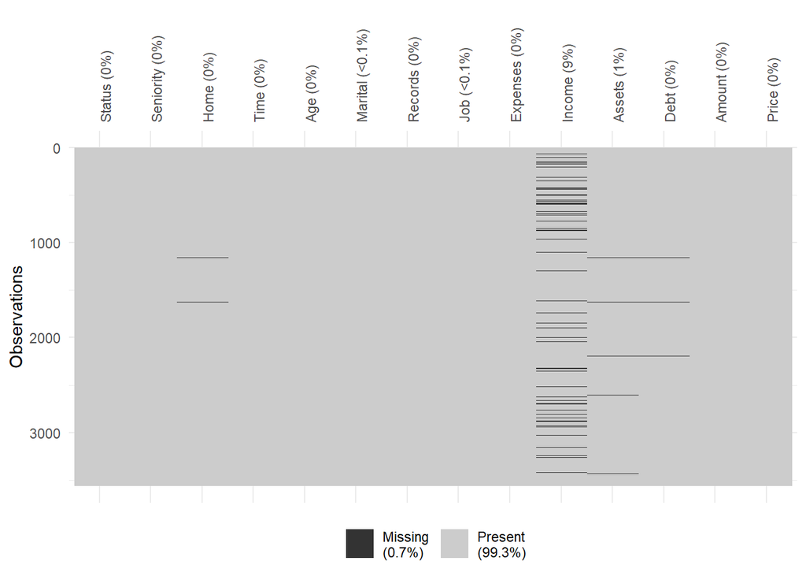

```r
visdat::vis_miss(Xmod) +
  theme(axis.text.x.top = element_text(angle = 90, hjust = 0))
```

Looking a bit more closely at the categorical variables to see if there aren’t any missing values coded as something else (e.g., empty strings or labels that clearly mean “missing”):

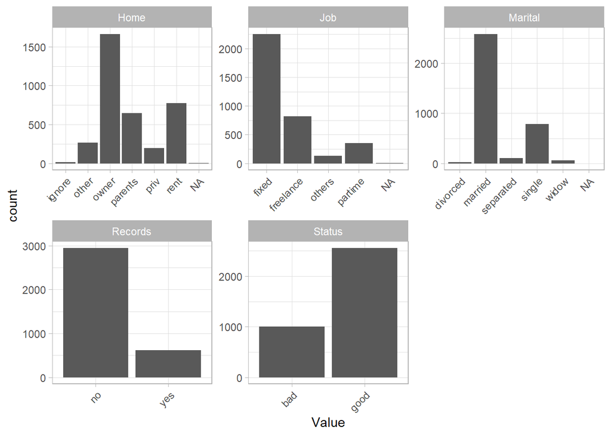

```r
Xmod %>%
  # Select only the factor variables.
  select(where(is.factor)) %>%
  # Make the dataset "longer" for ggplot visualisation
  pivot_longer(everything(), names_to = "Var", values_to = "Value") %>%
  # Build visualisation
  ggplot(aes(x = Value)) +
  geom_bar() +
  facet_wrap(.~Var, scales = "free") +
  theme_light() +
  theme(axis.text.x = element_text(angle=45, hjust = 1))
```

Let’s now check the numerical variables. We can take a rough look at their scale (and `NA` prevalence) using `summary()`:

```r
Xmod %>%
  # Select only the numeric variables
  select(where(is.numeric)) %>%
  summary()
```

```
##    Seniority           Time            Age           Expenses
##  Min.   : 0.000   Min.   : 6.00   Min.   :18.00   Min.   : 35.00
##  1st Qu.: 2.000   1st Qu.:36.00   1st Qu.:28.00   1st Qu.: 35.00
##  Median : 5.000   Median :48.00   Median :36.00   Median : 51.00
##  Mean   : 8.008   Mean   :46.37   Mean   :37.03   Mean   : 55.74
##  3rd Qu.:12.000   3rd Qu.:60.00   3rd Qu.:45.00   3rd Qu.: 74.00
##  Max.   :48.000   Max.   :72.00   Max.   :68.00   Max.   :180.00
##
##      Income          Assets            Debt             Amount
##  Min.   :  6.0   Min.   :     0   Min.   :    0.0   Min.   : 100
##  1st Qu.: 90.0   1st Qu.:     0   1st Qu.:    0.0   1st Qu.: 700
##  Median :125.0   Median :  3000   Median :    0.0   Median :1000
##  Mean   :142.1   Mean   :  5381   Mean   :  338.7   Mean   :1042
##  3rd Qu.:171.0   3rd Qu.:  6000   3rd Qu.:    0.0   3rd Qu.:1300
##  Max.   :905.0   Max.   :250000   Max.   :23500.0   Max.   :5000
##  NA's   :312     NA's   :37       NA's   :14
##      Price
##  Min.   : 105
##  1st Qu.:1121
##  Median :1404
##  Mean   :1462
##  3rd Qu.:1688
##  Max.   :8800
##
```

We have some variables defined in very different scales, which will probably need to be scaled later. Also, a quick glance at the quantiles indicates that at least two variables are *zero-inflated* (meaning that they have lots of zeros distorting their distributions): `Assets`, which has at least 25% of the data equal to zero (you can see that by noticing that both the `1st Quartile` and `Min` are equal to 0); and `Debt`, for which at least 50% of the data is zero (`Min` and `Median` both equal to 0). This can be problematic as it sometimes indicates variables that have two different, possibly conditional data-generating processes: one that regulates non-zeroness, another one that regulates values conditioned on it not being zero.

Let’s try to viasualise this. Given the differences of scale detected above, we’ll plot the log values, using `log1p()` instead of `log()` to prevent the zeroes from generating errors.

*(note: ggplot will throw a message indicating that 363 observations were removed from the plot - those are the `NA`s, you can check that by comparing the number in the ggplot warning with the total number of `NA`s in the numeric columns of the dataset.)*

```
## Warning: Removed 363 rows containing non-finite outside the scale range
## (`stat_boxplot()`).
```

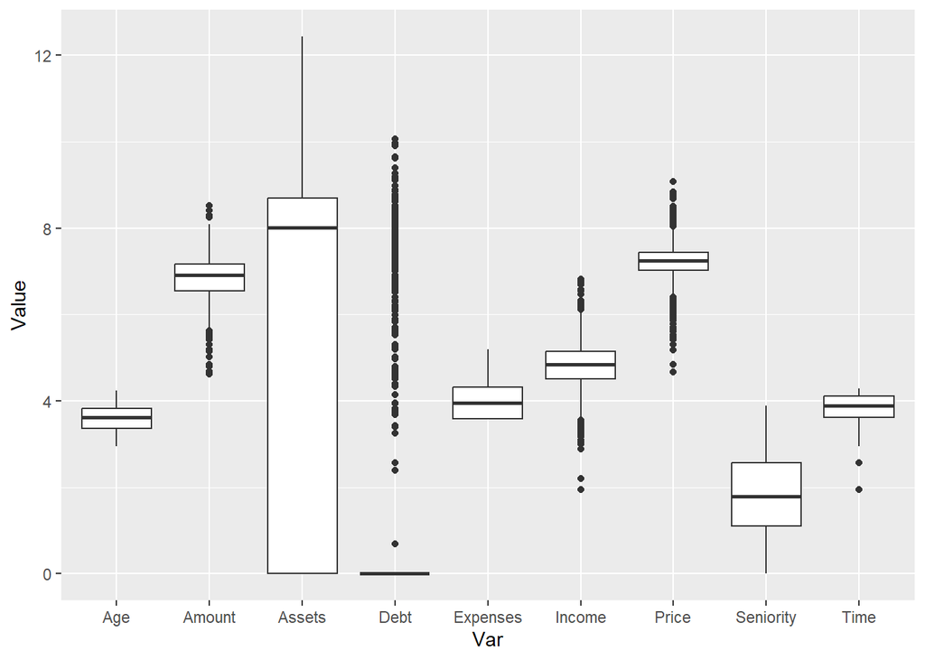

```r
# Log-transform all variables for visualisation
# Use log1p() instead of log() to prevent the zeroes in the data from generating errors.
Xmod %>%
  select(where(is.numeric)) %>%
  pivot_longer(everything(), names_to = "Var", values_to = "Value") %>%
  mutate(Value = log1p(Value)) %>%
  ggplot(aes(x = Var, y = Value)) +
  geom_boxplot()
```

Most variables seem to be fine with a log transformation, and we can probably use that in the preprocessing. This would need to be followed by winsorisation (to reduce the effect of extreme observations/outliers) and scaling (to bring the variables to a common scale). Variable `Time` may be better kept in its original scale:

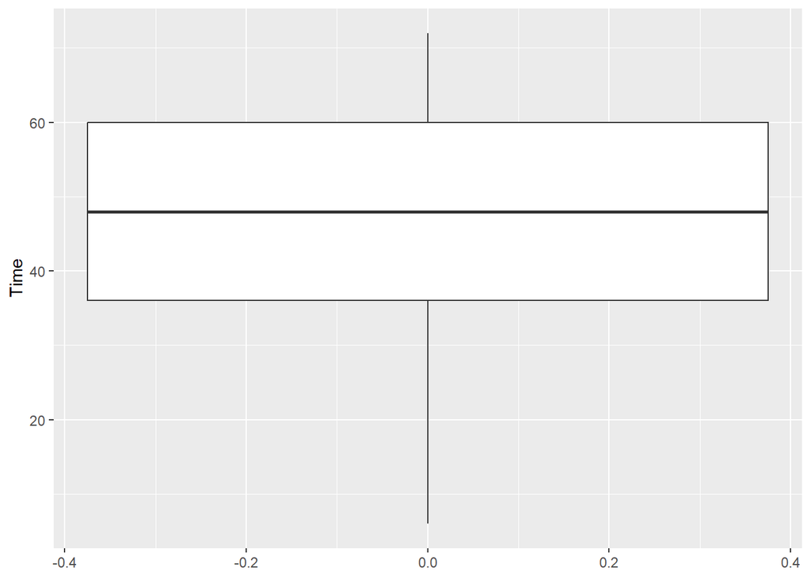

```r
Xmod %>%
  ggplot(aes(y = Time)) +
  geom_boxplot()
```

It looks a bit more symmetric about the median than the log-transformed version, so we can probably leave this one as-is.

The other two variables that stand out from the plot are the two we highlighted earlier as being zero-inflated, `Assets` and `Debt`. Let’s look more closely at them:

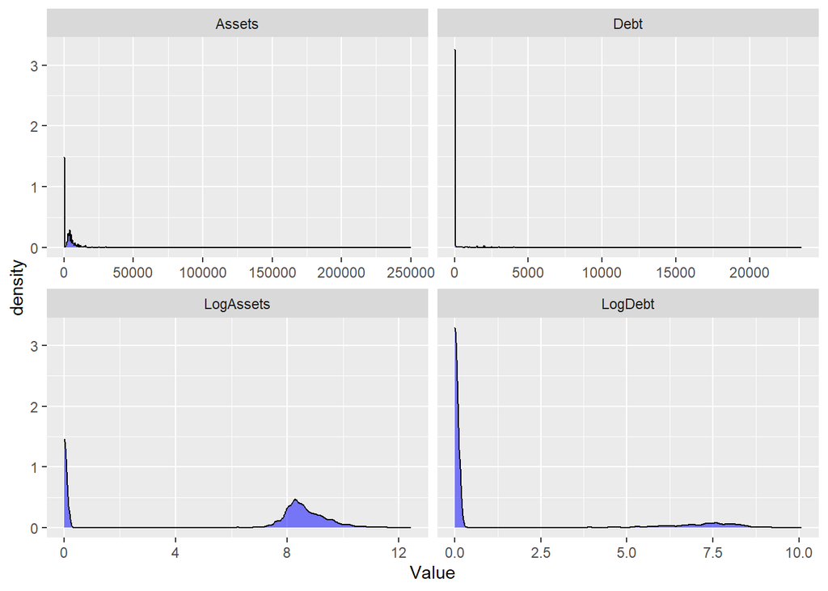

```r
Xmod %>%
  select(Assets, Debt) %>%
  mutate(LogAssets = log1p(Assets),
         LogDebt   = log1p(Debt)) %>%
  pivot_longer(everything(), names_to = "Var", values_to = "Value") %>%
  ggplot(aes(x = Value)) +
  geom_density(fill = "blue", alpha = .5, bw = .1) +
  facet_wrap(Var ~ ., scales = "free_x")
```

As we had detected earlier, there’s quite a lot of zeroes in these variables, and in both cases it clearly looks like there are two processes at play: one that regulates zero vs. nonzero, and another that regulates the nonzero values:

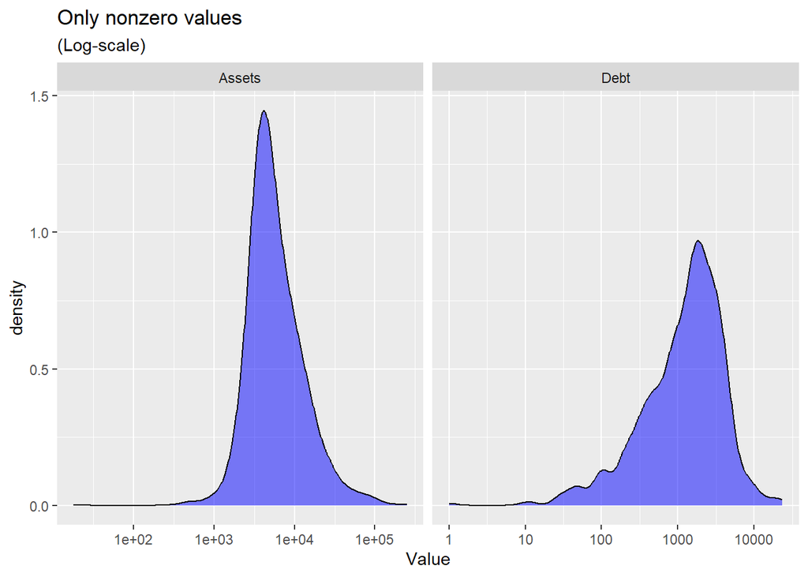

```r
# Look only at the nonzero values
Xmod %>%
  select(Assets, Debt) %>%
  pivot_longer(everything(), names_to = "Var", values_to = "Value") %>%
  filter(Value != 0) %>%
  ggplot(aes(x = Value)) +
  geom_density(fill = "blue", alpha = .5, bw = .1) +
  facet_wrap(Var ~ ., scales = "free_x") +
  scale_x_log10() +
  ggtitle("Only nonzero values", "(Log-scale)")
```

Dealing with zero-inflated features is usually a bit tricky. One way is to split the variables into a binary “indicator” variable (0 vs. non-0) and another variable with the actual value for the nonzero cases. This, however, also requires specialised modelling and tends not to play well with standard preprocessing routines. Another way of dealing with this type of issue (simpler, but leading to some information loss) is to discretise the numerical variables into buckets, and treat them as ordinal variables. For instance, based on the plots above, we could have:

- `Debt`: (0, 0 - 500, 500 - 1000, 1000-5000, >5000)
- `Assets`: (0, 0 - 1000, 1000 - 10000, 10000-100000, >100000)

Note that we’ll need to think about the missing values in these two variables as well. This may be quite difficult, as we don’t know if it would be safer to impute them as zeroes or using the mean of nonzero values. We’ll try using kNN-based imputation (imputting their values based on the k- most similar observations to the ones having missing values).

To summarise what EDA has informed us in terms of the necessary preprocessing steps:

- We’ll need to treat `NA`s in categorical variables. Mode-based imputation can be used. We could do one-hot encoding if we wanted to use models that don’t deal well with qualitative variables, but for now we’ll leave the factor predictors as-is.
- After imputation, we’ll combine level “ignore” into “other” for factor variable `Home`; and combine “divorced” with “separated” in factor variable `Marital`.
- We’ll need to treat numerical variables with different scales, missing values and zero-inflation. From our EDA, a strategy can be suggested:
1. For variable `Time`, we’ll perform imputation by winsorised mean and scaling.
2. For variables `Age`, `Amount`, `Income` and `Price`, we’ll perform log-transformation followed by winsorisation (“quantile capping”) and scaling. We’ll perform imputation by winsorised mean. This can be done either before or after the log-transformation, since quantiles are preserved by this transformation.
3. For variable `Expenses` and `Seniority`, we’ll perform log-transformation followed by scaling. The log of those variables seems to have short tails (no highlighted points in the boxplots), so winsorisation is unnecessary. Note that variable `Seniority` contains zeros (as can be seen from the summary) so we’ll need to use `log1p()` for that one. We’ll also perform imputation by winsorised mean.
4. For variables `Debt` and `Asset`, we’ll perform discretisation using user-defined bands. We’ll also perform imputation by k-nearest neighbours. Since kNN is a scale-dependent method, imputation in these cases needs to come after the scaling of the remaining variables in the preprocessing stack.

Notice that some variables, such as `Time`, have no missing values in the training data, but we don’t know if missing values may be present in the test data or on new data - we’ll add an imputation step just in case (it does not change anything in case there’s no missing data).

Having done the basic exploration of the data, we can now proceed to act on the insights gained during EDA. For that, we’ll use package `recipes` plus a few auxiliary functions from other packages.

As the name suggests, package `recipes` treats preprocessing steps as a recipe, and the function names reflect this wordplay from the authors. Recipes are initialised using function `recipe()`, then proprocessing tasks are included using functions starting with `step_`. Once assembled, a recipe is “prepared” (i.e., the transformation constants are calculated) using function `prep()`, and finally the recipe is applied to the data using function `bake()`. There are a couple of additional details, but this is the general idea.

Before we proceed to acting on the insights of our EDA, let’s do a very simple example first, composed only of:

- mode imputation for categorical variables
- winsorised mean imputation for numerical predictors
- scaling of numerical attributes. We’ll use “normalisation” instead of minmax since PCA works better with normalised variables.
- dimensionality reduction using principal component analysis (PCA) for the numerical features

```r
simple_recipe <- recipe(Status ~ ., data = Xmod) %>%
  # mode imputation for categorical predictors
  step_impute_mode(all_factor_predictors()) %>%
  # 10% winsorised mean imputation for numerical predictors
  step_impute_mean(all_numeric_predictors(), trim = 0.1) %>%
  # PCA-based dimensionality reduction (numeric variables only)
  # retaining enough components to explain at least 90% of the data variability
  # Note: PCA works better with centred/scaled (="normalised") variables
  step_normalize(all_numeric_predictors()) %>%
  step_pca(all_numeric_predictors(), threshold = .9)

simple_recipe
```

```
##
## ── Recipe ──────────────────────────────────────────────────────────────────────
##
## ── Inputs
## Number of variables by role
## outcome:    1
## predictor: 13
##
## ── Operations
## • Mode imputation for: all_factor_predictors()
## • Mean imputation for: all_numeric_predictors()
## • Centering and scaling for: all_numeric_predictors()
## • PCA extraction with: all_numeric_predictors()
```

Once the recipe is ready, we `prep()` it (which calculates all the transformation constants based on the training data used in the initial `recipe()` call):

```r
simple_recipe_prepped <- simple_recipe %>%
  prep()

simple_recipe_prepped
```

```
##
## ── Recipe ──────────────────────────────────────────────────────────────────────
##
## ── Inputs
## Number of variables by role
## outcome:    1
## predictor: 13
##
## ── Training information
## Training data contained 3563 data points and 340 incomplete rows.
##
## ── Operations
## • Mode imputation for: Home, Marital, Records, Job | Trained
## • Mean imputation for: Seniority, Time, Age, Expenses, Income, ... | Trained
## • Centering and scaling for: Seniority, Time, Age, Expenses, ... | Trained
## • PCA extraction with: Seniority, Time, Age, Expenses, Income, ... | Trained
```

To check which variables were retained after the feature reduction, we can use:

```r
summary(simple_recipe_prepped)
```

```
## # A tibble: 12 × 4
##    variable type      role      source
##    <chr>    <list>    <chr>     <chr>
##  1 Home     <chr [3]> predictor original
##  2 Marital  <chr [3]> predictor original
##  3 Records  <chr [3]> predictor original
##  4 Job      <chr [3]> predictor original
##  5 Status   <chr [3]> outcome   original
##  6 PC1      <chr [2]> predictor derived
##  7 PC2      <chr [2]> predictor derived
##  8 PC3      <chr [2]> predictor derived
##  9 PC4      <chr [2]> predictor derived
## 10 PC5      <chr [2]> predictor derived
## 11 PC6      <chr [2]> predictor derived
## 12 PC7      <chr [2]> predictor derived
```

We can see that the 9 numerical features were reduced to seven *principal components* (PC1 - PC7) which represent specific, mutually independent linear combinations of the original attributes that are sufficient to account for (in this case) at least 90% of the total variability of the numeric features.

To apply the learned transformations to any data set having the same structure as the data used to *fit* the preprocessing transformations (in our case, that would be `Xmod` as well as `Xtest`) we can use `bake()`:

```r
Xmod.pp <- simple_recipe_prepped %>%
  bake(Xmod)

summary(Xmod.pp)
```

```
##       Home           Marital     Records           Job        Status
##  ignore :  17   divorced :  27   no :2949   fixed    :2254   bad :1003
##  other  : 265   married  :2588   yes: 614   freelance: 820   good:2560
##  owner  :1669   separated: 105              others   : 133
##  parents: 644   single   : 785              partime  : 356
##  priv   : 195   widow    :  58
##  rent   : 773
##       PC1                PC2               PC3                PC4
##  Min.   :-14.9050   Min.   :-5.1556   Min.   :-13.3464   Min.   :-5.89007
##  1st Qu.: -0.7753   1st Qu.:-0.9537   1st Qu.: -0.4192   1st Qu.:-0.58364
##  Median :  0.1074   Median :-0.1224   Median :  0.1166   Median : 0.08118
##  Mean   :  0.0000   Mean   : 0.0000   Mean   :  0.0000   Mean   : 0.00000
##  3rd Qu.:  0.9195   3rd Qu.: 0.8067   3rd Qu.:  0.6046   3rd Qu.: 0.56952
##  Max.   :  3.8989   Max.   : 5.3392   Max.   :  2.6709   Max.   :10.15986
##       PC5                PC6                PC7
##  Min.   :-5.97094   Min.   :-5.15177   Min.   :-12.27344
##  1st Qu.:-0.55716   1st Qu.:-0.43986   1st Qu.: -0.38597
##  Median : 0.01265   Median :-0.02568   Median : -0.03927
##  Mean   : 0.00000   Mean   : 0.00000   Mean   :  0.00000
##  3rd Qu.: 0.52171   3rd Qu.: 0.42735   3rd Qu.:  0.37625
##  Max.   :11.57570   Max.   : 9.00589   Max.   :  6.65606
```

```r
# The same can be done with Xtest, for instance. But usually we don't need to do it explicitly,
# since we'll later encapsulate the preprocessing recipe within a modelling workflow.
# Xtest.pp <- simple_recipe_prepped %>%
#   bake(Xtest)
```

Now, let’s build a slightly more complex preprocessing recipe, based on the insights we collected during EDA.

```r
dpp.stack <- recipe(Status ~ ., data = Xmod)
dpp.stack %>%
  summary()
```

```
## # A tibble: 14 × 4
##    variable  type      role      source
##    <chr>     <list>    <chr>     <chr>
##  1 Seniority <chr [2]> predictor original
##  2 Home      <chr [3]> predictor original
##  3 Time      <chr [2]> predictor original
##  4 Age       <chr [2]> predictor original
##  5 Marital   <chr [3]> predictor original
##  6 Records   <chr [3]> predictor original
##  7 Job       <chr [3]> predictor original
##  8 Expenses  <chr [2]> predictor original
##  9 Income    <chr [2]> predictor original
## 10 Assets    <chr [2]> predictor original
## 11 Debt      <chr [2]> predictor original
## 12 Amount    <chr [2]> predictor original
## 13 Price     <chr [2]> predictor original
## 14 Status    <chr [3]> outcome   original
```

Notice that the formula object has started the recipe with a single “outcome” variable and everything else as “predictor” variables. **Roles** are important in `recipes` and can be used to select specific variables for targeted transformations. In most cases, we can use only “predictor” and “outcome”, but we may change/remove/add new roles to any variable using `update_role()`, `add_role()` or `remove_role()`.

As an example, we can add specific roles to separate the different types of preprocessing we’re planning to execute on different groups of numerical variables:

```r
dpp.stack <- dpp.stack %>%
  add_role(Age, Amount, Income, Price, new_role = "NumPredType2") %>%
  add_role(Expenses, Seniority, new_role = "NumPredType3") %>%
  add_role(Debt, Assets, new_role = "NumPredType4")
dpp.stack %>%
  summary()
```

```
## # A tibble: 22 × 4
##    variable  type      role         source
##    <chr>     <list>    <chr>        <chr>
##  1 Seniority <chr [2]> predictor    original
##  2 Seniority <chr [2]> NumPredType3 original
##  3 Home      <chr [3]> predictor    original
##  4 Time      <chr [2]> predictor    original
##  5 Age       <chr [2]> predictor    original
##  6 Age       <chr [2]> NumPredType2 original
##  7 Marital   <chr [3]> predictor    original
##  8 Records   <chr [3]> predictor    original
##  9 Job       <chr [3]> predictor    original
## 10 Expenses  <chr [2]> predictor    original
## # ℹ 12 more rows
```

Note that variables with multiple roles have one row per role in the recipe summary.

We can add the steps to treat the factor variables first. To recall:

*We’ll need to treat `NA`s in categorical variables. Mode-based imputation can be used. After imputation, we’ll combine level “ignore” into “other” for factor variable `Home`; and combine “divorced” with “separated” in factor variable `Marital`.”*

```r
dpp.stack <- dpp.stack %>%
  # mode imputation
  step_impute_mode(all_factor_predictors()) %>%
  # collapse factor levels using fct_collapse() from package `forcats`
  step_mutate(Home = fct_collapse(Home, other = c("other", "ignore"))) %>%
  step_mutate(Marital = fct_collapse(Marital, Unmarried = c("divorced", "separated")))

# You can always check how that will go once the recipe is prepped:
# dpp.stack %>%
#   prep() %>%
#   summary()
```

The next step is to treat the numeric variables.To recall:

*For variable `Time`, we’ll perform imputation by winsorised mean and scaling.*

```r
dpp.stack <- dpp.stack %>%
# mean imputation, using 10% winsorisation.
step_impute_mean(Time, trim = 0.1) %>%
# Minmax scaling
step_normalize(Time)
```

We are using `step_normalize()` instead of the minmax scaler, `step_range()`, since PCA works better with normalised data.

*For variables `Age`, `Amount`, `Income` and `Price`, we’ll perform log-transformation followed by winsorisation (“quantile capping”) and scaling. We’ll perform imputation by winsorised mean. This can be done either before or after the log-transformation, since quantiles are preserved by this transformation.*

Recalling that we added the additional role “NumPredType2” to these variables, we can do:

```r
dpp.stack <- dpp.stack %>%
  # mean imputation, using 10% winsorisation.
  step_impute_mean(has_role("NumPredType2"), trim = 0.1) %>%
  # Log transformation
  step_mutate_at(has_role("NumPredType2"),fn = ~log(.x)) %>%
  # Winsorisation at 5% (less extreme than the one used in the mean imputation)
  step_hai_winsorized_truncate(has_role("NumPredType2"), fraction = .05) %>%
  # Remove pre-winsorisation variables
  step_rm(has_role("NumPredType2")) %>%
  # Minmax scaling
  step_normalize(has_role("NumPredType2"))

dpp.stack
```

```
##
## ── Recipe ──────────────────────────────────────────────────────────────────────
##
## ── Inputs
## Number of variables by role
## outcome:       1
## predictor:    13
## NumPredType2:  4
## NumPredType3:  2
## NumPredType4:  2
##
## ── Operations
## • Mode imputation for: all_factor_predictors()
## • Variable mutation for: fct_collapse(Home, other = c("other", "ignore"))
## • Variable mutation for: fct_collapse(Marital, Unmarried = c("divorced",
##   "separated"))
## • Mean imputation for: Time
## • Centering and scaling for: Time
## • Mean imputation for: has_role("NumPredType2")
## • Variable mutation for: has_role("NumPredType2")
## • Winsorized Truncation Transformation on: has_role("NumPredType2")
## • Variables removed: has_role("NumPredType2")
## • Centering and scaling for: has_role("NumPredType2")
```

*For variable `Expenses` and `Seniority`, we’ll perform log-transformation followed by scaling. The log of those variables seems to have short tails (no highlighted points in the boxplots), so winsorisation is unnecessary. Note that variable `Seniority` contains zeros (as can be seen from the summary) so we’ll need to use `log1p()` for that one. We’ll also perform imputation by winsorised mean.*

Recall that we added role “NumPredType3” to those variables, so we can do:

```r
dpp.stack <- dpp.stack %>%
  # mean imputation, using 10% winsorisation.
  step_impute_mean(has_role("NumPredType3"), trim = 0.1) %>%
  # Log transformation
  step_mutate(Expenses = log(Expenses),
              Seniority = log1p(Seniority)) %>%
  # Minmax scaling
  step_normalize(has_role("NumPredType3"))
```

Finally, *for variables `Debt` and `Asset`, we’ll perform discretisation using user-defined bands. We’ll also perform imputation by k-nearest neighbours. Since kNN is a scale-dependent method, imputation in these cases needs to come after the scaling of the remaining variables in the preprocessing stack.*

- *`Debt`: (0, 0 - 500, 500 - 1000, 1000-5000, >5000)*
- *`Assets`: (0, 0 - 1000, 1000 - 10000, 10000-100000, >100000)*

```r
dpp.stack <- dpp.stack %>%
  # Ordinal encoding
  step_cut(Debt, breaks = c(0.001, 500, 1000, 5000),
           include_outside_range = TRUE) %>%
  step_cut(Assets, breaks = c(0.001, 1000, 10000, 100000),
           include_outside_range = TRUE) %>%
  step_impute_knn(has_role("NumPredType4"))
```

```r
dpp.stack <- dpp.stack %>%
  # Perform PCA on the numeric predictors, retaining >=95% of total variance
  step_pca(all_numeric_predictors(), threshold = 0.95)

# Check the final sequence of steps in the recipe
dpp.stack
```

```
##
## ── Recipe ──────────────────────────────────────────────────────────────────────
##
## ── Inputs
## Number of variables by role
## outcome:       1
## predictor:    13
## NumPredType2:  4
## NumPredType3:  2
## NumPredType4:  2
##
## ── Operations
## • Mode imputation for: all_factor_predictors()
## • Variable mutation for: fct_collapse(Home, other = c("other", "ignore"))
## • Variable mutation for: fct_collapse(Marital, Unmarried = c("divorced",
##   "separated"))
## • Mean imputation for: Time
## • Centering and scaling for: Time
## • Mean imputation for: has_role("NumPredType2")
## • Variable mutation for: has_role("NumPredType2")
## • Winsorized Truncation Transformation on: has_role("NumPredType2")
## • Variables removed: has_role("NumPredType2")
## • Centering and scaling for: has_role("NumPredType2")
## • Mean imputation for: has_role("NumPredType3")
## • Variable mutation for: log(Expenses) log1p(Seniority)
## • Centering and scaling for: has_role("NumPredType3")
## • Cut numeric for: Debt
## • Cut numeric for: Assets
## • K-nearest neighbor imputation for: has_role("NumPredType4")
## • PCA extraction with: all_numeric_predictors()
```

Once we finish adding the preprocessing steps, we can `prep()` the recipe, then `bake()` it on the data:

```r
dpp.stack.prepped <- prep(dpp.stack)
summary(dpp.stack.prepped)
```

```
## # A tibble: 10 × 4
##    variable type      role         source
##    <chr>    <list>    <chr>        <chr>
##  1 Home     <chr [3]> predictor    original
##  2 Marital  <chr [3]> predictor    original
##  3 Records  <chr [3]> predictor    original
##  4 Job      <chr [3]> predictor    original
##  5 Assets   <chr [3]> predictor    original
##  6 Assets   <chr [3]> NumPredType4 original
##  7 Debt     <chr [3]> predictor    original
##  8 Debt     <chr [3]> NumPredType4 original
##  9 Status   <chr [3]> outcome      original
## 10 PC1      <chr [2]> predictor    derived
```

```r
Xmod.pp  <- bake(dpp.stack.prepped, Xmod)
summary(Xmod.pp)
```

```
##       Home           Marital     Records           Job
##  other  : 282   Unmarried: 132   no :2949   fixed    :2254
##  owner  :1669   married  :2588   yes: 614   freelance: 820
##  parents: 644   single   : 785              others   : 133
##  priv   : 195   widow    :  58              partime  : 356
##  rent   : 773
##
##            Assets                Debt       Status          PC1
##  [min,0.001]  :1326   [min,0.001]  :2961   bad :1003   Min.   :-12.83
##  (0.001,1e+03]:  25   (0.001,500]  : 146   good:2560   1st Qu.:-11.97
##  (1e+03,1e+04]:1790   (500,1e+03]  :  99               Median :-11.66
##  (1e+04,1e+05]: 417   (1e+03,5e+03]: 331               Mean   :-11.62
##  (1e+05,max]  :   5   (5e+03,max]  :  26               3rd Qu.:-11.30
##                                                        Max.   :-10.08
```

```r
# Xtest.pp <- bake(dpp.stack, Xtest)
```

From here, we can proceed to the final steps of modelling and assessment. Next week. :)

## TO DO

Now it’s your turn. After following the example above and experimenting with it in your own R session, try performing data preprocessing on the dataset for Task II of the final coursework. Use the ideas above, read the guides of package `recipes` (to get more ideas) and try your hand at working with the coursework data.